# More Data Manipulation

Fri Oct 14, 2016

## Last Time: 5MV

1. `select()` columns by variable name: **front of cheatsheet, bottom right**
2. `filter()` rows matching criteria: **front of cheatsheet, bottom middle.**
3. `summarise()` numerical variables that are `group_by()` categorical variables
4. `mutate()` existing variables to create new ones
5. `arrange()` rows

## Important Concept: Piping

Piping allows you to take the output of one function and **pipe** it as the input of the next function. You can string along several pipes to form a single **chain**.

- R Command: `%>%`
- Described as: "*then*".

**front of cheatsheet, bottom left**

## Important Concept: Piping

Ex: say you want to apply functions `h()` and `g()` and then `f()` on data `x`. You can do

- `f(g(h(x)))` OR
- `x %>% h() %>% g() %>% f()`

## Important Concept: Piping

This

- saves you from confusing nested parentheses
- emphasizes the **sequential** breaking down of tasks, making it more readable
- i.e. Do this *then* do this *then* do this *then* …

## Important Concept: Piping

Pipes are always directed to the first argument of any function. The following three bits of R code do the same thing: extract all january flights:

```r
library(dplyr)
library(nycflights13)
data(flights)

# Bit 1: No piping
filter(flights, month == 1)

# Bit 2: Piping. Note no comma
flights %>% filter(month == 1)

# Bit 3: Piping across multiple lines (preferred for legibility)
flights %>%
  filter(month==1)
```

## Today: 5MV

1. `select()` columns by variable name: front of cheatsheet, bottom right
2. `filter()` rows matching criteria: front of cheatsheet, bottom middle
3. `summarise()` numerical variables that are `group_by()` categorical variables: **back of cheatsheet, left-hand column, top and bottom**
4. `mutate()` existing variables to create new ones
5. `arrange()` rows

## Motto of the United States

[figure not shown]

## Summary Functions

**Summary statistics** are single numbers that summarise a **vector** (i.e. a sequence/list) of numerical values:

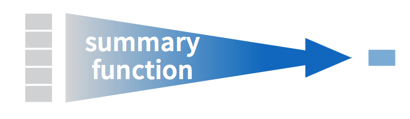

## Example

Load the following in your console

```r
library(dplyr)

# Create data frame with two variables
test_data <- data_frame(
  name=c("Albert", "Albert", "Albert", "Virginia", "Virginia"),
  value=c(1, 2, 3, 4, 5)
)

# See contents in console
test_data
```

## Example

Run each of these 3 bits separately in your console:

```r
# Bit 1: No group structure: overall sum
test_data %>% summarise(total=sum(value))

# Bit 2: Grouped by name: name-by-name sum "total"
test_data %>% group_by(name) %>% summarise(total=sum(value))

# Bit 3: Grouped by name: name-by-name sum "total" and mean "avg"
test_data %>% group_by(name) %>%
  summarise(total=sum(value), avg=mean(value))
```